# Assignment 6

## Try to submit as an HTML file

Print your Emory code below

```python
print("2481769")
```

```
2481769
```

Import the "pandas" and "matplotlib.pyplot" libraries

```python
# Write your answer here:

import pandas as pd
import matplotlib.pyplot as plt
```

(a) Functions

- Read the dataset labelled features.csv.
- Create a `lambda` function that checks if displacement $>$ 200
- Create a new list that shows true if displacement $>$ 200 and false

if displacement $\leq$ 200.

- Count how many cars have displacement $> 200$.

To get full credit use either the apply or the map function  
(see Lectures 7 and 8)

```python
# Write your answer here:

features = pd.read_csv("/Users/seanchang/Documents/GitHub/qtm151spring2025/assignment6/data/features.csv")

displacement_check = features['displacement'].apply(lambda x: x > 200)
displacement_list = displacement_check.tolist()
count_displacement_gt_200 = displacement_check.sum()

print("Number of cars with displacement > 200:", count_displacement_gt_200)
```

```
Number of cars with displacement > 200: 158
```

(b) Subsetting Data

- Read the dataset labelled features.csv.
- Define a global variable called `threshold` that takes the

value 2588

- Subset the data to get one dataset with weight $>$ threshold and

another with weight $\le$ 2588. Use the `.query()` function.

- Compute the mean acceleration for each of these datasets.

Note: Review how to define a gloabl variable inside `.query()`

```python
# Write your answer here:
threshold = 2588

subset_gt_threshold = features.query('weight > @threshold')
subset_le_threshold = features.query('weight <= @threshold')

mean_acceleration_gt_threshold = subset_gt_threshold['acceleration'].mean()
mean_acceleration_le_threshold = subset_le_threshold['acceleration'].mean()

print("Mean acceleration for cars with weight > 2588:", mean_acceleration_gt_threshold)
print("Mean acceleration for cars with weight <= 2588:", mean_acceleration_le_threshold)
```

```
Mean acceleration for cars with weight > 2588: 14.972457627118644
Mean acceleration for cars with weight <= 2588: 16.435802469135798
```

(c) Use sorting + ".iloc[]"

- Read the "fifa23_players_basic.csv" dataset
- Use ".sort_values()" to order the "Age" column

from youngest to oldest

- Get a subset with the 5 youngest players

```python
# Write your answer here:

fifa23 = pd.read_csv("/Users/seanchang/Documents/GitHub/qtm151spring2025/assignment6/data/fifa23_players_basic.csv")

fifa23_sorted_by_age = fifa23.sort_values(by='Age')

youngest_players = fifa23_sorted_by_age.iloc[:5]

print(youngest_players)
```

```
            Known As        Full Name  Overall  Potential  Value(in Euro)  \
17956     A. Dithmer  Andreas Dithmer       53         76          275000
18014      J. Ardila      José Ardila       53         73          250000
16084       S. Ngoma      Serge Ngoma       58         82          650000
11481      O. Vargas      Obed Vargas       64         81         1500000
17591  A. Madaliński  Alan Madaliński       54         68          210000

      Positions Played Best Position    Nationality  \
17956               GK            GK        Denmark
18014               CM           CAM      Venezuela
16084               RW            RM  United States
11481        CM,CDM,RM           CAM  United States
17591               GK            GK         Poland

                                             Image Link  Age  ...  \
```

[output cut: 35 more lines]

(d) Use queries + global variables

- Read the "fifa23_players_basic.csv" dataset
- Compute the mean of the column "Wage(in Euro)"

and store it as a variable

- Subset the players whose value is above the mean value  
  using ".query()"

HINT: Remember that there is a special syntax for  
when the column names have spaces (see Lecture 10)  
Reference the column as `` `Wage(in Euro)` `` inside .query()

```python
# Write your answer here:

mean_wage = fifa23['Wage(in Euro)'].mean()

players_above_mean_wage = fifa23.query('`Wage(in Euro)` > @mean_wage')

print(players_above_mean_wage)
```

```
                 Known As                 Full Name  Overall  Potential  \
0                L. Messi              Lionel Messi       91         91
1              K. Benzema             Karim Benzema       91         91
2          R. Lewandowski        Robert Lewandowski       91         91
3            K. De Bruyne           Kevin De Bruyne       91         91
4               K. Mbappé             Kylian Mbappé       91         95
...                   ...                       ...      ...        ...
14279            A. Lewis                Adam Lewis       61         65
15117           B. Knight                Ben Knight       60         74
15441  T. Suengchitthawon  Thanawat Suengchitthawon       60         70
15957          P. Glatzel              Paul Glatzel       59         65
16157      C. Chukwuemeka         Caleb Chukwuemeka       58         71

       Value(in Euro) Positions Played Best Position Nationality  \
0            54000000               RW           CAM   Argentina
```

[output cut: 77 more lines]

(e) Plot by Category

Read the "data/wdi_urban.csv" dataset.

This contains data from 1980 and 2020.

- **Create a list with the unique values of "year"**
- **Create a plot with a ...**
  - Histogram of "prop_urbanpopulation" for each year
  - Set the histogram option `alpha = 0.5` for transparency
  - All the histograms should be overlapping
  - Create a legend with the list of years
  - Label the axes and the title

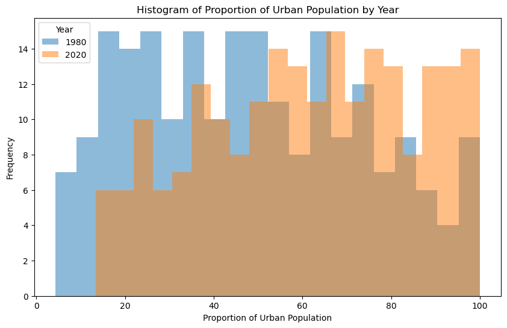

```python
# Write your answer here:

wdi_urban = pd.read_csv("/Users/seanchang/Documents/GitHub/qtm151spring2025/assignment6/data/wdi_urban.csv")

unique_years = wdi_urban['year'].unique()

plt.figure(figsize=(10, 6))

for year in unique_years:
    subset = wdi_urban[wdi_urban['year'] == year]
    plt.hist(subset['prop_urbanpopulation'], bins=20, alpha=0.5, label=str(year))
plt.legend(title="Year")
plt.xlabel("Proportion of Urban Population")
plt.ylabel("Frequency")
plt.title("Histogram of Proportion of Urban Population by Year")
plt.show()
```